# Ayudantía 1

# Estadistica Descriptiva

Lo primero que debemos hacer para poder realizar visualizaciones es tener una base de datos que queremos conocer, para esto debemos cargar paquetes, en este caso para poder cargar bases de datos de Stata, Excel, Spss, etc. utilizamos `haven`

```r
library(haven) #Este comando nos permite ejecutar el paquete
```

Cargar la base de datos usando haven

```r
base <- read_sav("files/ELSOC_2021.sav")
```

## Explorar la base

Siempre es recomendable conocer nuestros datos antes de trabajar con ellos. Existen algunas funciones que nos serán muy útiles para ello.

### **head**

Esta función nos va a mostrar por defecto los primeros 6 casos de nuestra base de datos, considerando todas las columnas de la base.

```r
head(base) #solo muetsra 6 primeros casos
```

```
# A tibble: 6 × 311
  idencuesta ola       version muestra   cuestion_mig cuestion_completo segmento
       <dbl> <dbl+lbl>   <dbl> <dbl+lbl> <dbl+lbl>    <dbl+lbl>            <dbl>
1    1101011 5 [2021]   202101 1 [Muest… 1 [Peruanos] 1 [Completa]        110101
2    1101012 5 [2021]   202101 1 [Muest… 1 [Peruanos] 1 [Completa]        110101
3    1101013 5 [2021]   202101 1 [Muest… 2 [Venezola… 1 [Completa]        110101
4    1101021 5 [2021]   202101 1 [Muest… 2 [Venezola… 1 [Completa]        110102
5    1101023 5 [2021]   202101 1 [Muest… 1 [Peruanos] 1 [Completa]        110102
6    1101032 5 [2021]   202101 1 [Muest… 1 [Peruanos] 1 [Completa]        110103
# ℹ 304 more variables: comuna <chr>, comuna_cod <dbl+lbl>, region <chr>,
#   region_cod <dbl+lbl>, estrato <dbl+lbl>, ponderador01 <dbl>,
#   ponderador02 <dbl>, fact_exp01 <dbl>, fact_exp02 <dbl>, r01_01 <dbl+lbl>,
#   r01_02 <dbl+lbl>, r01_03 <dbl+lbl>, r01_04 <dbl+lbl>, r01_05 <dbl+lbl>,
#   r01_06 <dbl+lbl>, r01_07 <dbl+lbl>, r01_08 <dbl+lbl>, r01_09 <dbl+lbl>,
#   r01_10 <dbl+lbl>, r01_11 <dbl+lbl>, r01_12 <dbl+lbl>, r01_13 <dbl+lbl>,
#   r03_01 <dbl+lbl>, r03_02 <dbl+lbl>, r03_03 <dbl+lbl>, r03_04 <dbl+lbl>, …
```

```r
head(base, 20) #nos mostrará mas casos si ponemos una "," y el numero de casos que queremos ver
```

```
# A tibble: 20 × 311
   idencuesta ola       version muestra  cuestion_mig cuestion_completo segmento
        <dbl> <dbl+lbl>   <dbl> <dbl+lb> <dbl+lbl>    <dbl+lbl>            <dbl>
 1    1101011 5 [2021]   202101 1 [Mues… 1 [Peruanos] 1 [Completa]        110101
 2    1101012 5 [2021]   202101 1 [Mues… 1 [Peruanos] 1 [Completa]        110101
 3    1101013 5 [2021]   202101 1 [Mues… 2 [Venezola… 1 [Completa]        110101
 4    1101021 5 [2021]   202101 1 [Mues… 2 [Venezola… 1 [Completa]        110102
 5    1101023 5 [2021]   202101 1 [Mues… 1 [Peruanos] 1 [Completa]        110102
 6    1101032 5 [2021]   202101 1 [Mues… 1 [Peruanos] 1 [Completa]        110103
 7    1101033 5 [2021]   202101 1 [Mues… 1 [Peruanos] 1 [Completa]        110103
 8    1101053 5 [2021]   202101 1 [Mues… 1 [Peruanos] 1 [Completa]        110105
 9    1101081 5 [2021]   202101 1 [Mues… 1 [Peruanos] 1 [Completa]        110108
10    1101103 5 [2021]   202101 1 [Mues… 2 [Venezola… 1 [Completa]        110110
11    1101113 5 [2021]   202101 1 [Mues… 2 [Venezola… 1 [Completa]        110111
12    1101132 5 [2021]   202101 1 [Mues… 2 [Venezola… 1 [Completa]        110113
13    1101133 5 [2021]   202101 1 [Mues… 1 [Peruanos] 1 [Completa]        110113
14    1101151 5 [2021]   202101 1 [Mues… 1 [Peruanos] 1 [Completa]        110115
15    1101152 5 [2021]   202101 1 [Mues… 1 [Peruanos] 1 [Completa]        110115
16    1101153 5 [2021]   202101 1 [Mues… 2 [Venezola… 1 [Completa]        110115
17    1101171 5 [2021]   202101 1 [Mues… 1 [Peruanos] 1 [Completa]        110117
18    1101173 5 [2021]   202101 1 [Mues… 1 [Peruanos] 1 [Completa]        110117
19    1107011 5 [2021]   202101 1 [Mues… 1 [Peruanos] 1 [Completa]        110701
20    1107012 5 [2021]   202101 1 [Mues… 2 [Venezola… 1 [Completa]        110701
# ℹ 304 more variables: comuna <chr>, comuna_cod <dbl+lbl>, region <chr>,
#   region_cod <dbl+lbl>, estrato <dbl+lbl>, ponderador01 <dbl>,
#   ponderador02 <dbl>, fact_exp01 <dbl>, fact_exp02 <dbl>, r01_01 <dbl+lbl>,
#   r01_02 <dbl+lbl>, r01_03 <dbl+lbl>, r01_04 <dbl+lbl>, r01_05 <dbl+lbl>,
#   r01_06 <dbl+lbl>, r01_07 <dbl+lbl>, r01_08 <dbl+lbl>, r01_09 <dbl+lbl>,
#   r01_10 <dbl+lbl>, r01_11 <dbl+lbl>, r01_12 <dbl+lbl>, r01_13 <dbl+lbl>,
#   r03_01 <dbl+lbl>, r03_02 <dbl+lbl>, r03_03 <dbl+lbl>, r03_04 <dbl+lbl>, …
```

### **str**

Esta función nos permite ver un resumen de la estructura de nuestros datos

```r
str(base[,1:5])
```

```
tibble [2,740 × 5] (S3: tbl_df/tbl/data.frame)
 $ idencuesta  : num [1:2740] 1101011 1101012 1101013 1101021 1101023 ...
  ..- attr(*, "label")= chr "Folio identificador de participante"
  ..- attr(*, "format.spss")= chr "F8.2"
 $ ola         : dbl+lbl [1:2740] 5, 5, 5, 5, 5, 5, 5, 5, 5, 5, 5, 5, 5, 5, 5, 5, 5, 5,...
   ..@ label      : chr "Identificador de ola de encuesta"
   ..@ format.spss: chr "F8.2"
   ..@ labels     : Named num [1:5] 1 2 3 4 5
   .. ..- attr(*, "names")= chr [1:5] "2016" "2017" "2018" "2019" ...
 $ version     : num [1:2740] 202101 202101 202101 202101 202101 ...
  ..- attr(*, "label")= chr "Codigo identificador de numero de version de base de datos"
  ..- attr(*, "format.spss")= chr "F8.0"
 $ muestra     : dbl+lbl [1:2740] 1, 1, 1, 1, 1, 1, 1, 1, 1, 1, 1, 1, 1, 1, 1, 1, 1, 1,...
   ..@ label      : chr "Identificador de muestra de encuesta"
   ..@ format.spss: chr "F8.2"
   ..@ labels     : Named num [1:2] 1 2
   .. ..- attr(*, "names")= chr [1:2] "Muestra Original" "Muestra Refresco"
 $ cuestion_mig: dbl+lbl [1:2740] 1, 1, 2, 2, 1, 1, 1, 1, 1, 2, 2, 2, 1, 1, 1, 2, 1, 1,...
   ..@ label      : chr "Identificador de grupo migrante consultado"
   ..@ format.spss: chr "F8.2"
   ..@ labels     : Named num [1:3] 1 2 3
   .. ..- attr(*, "names")= chr [1:3] "Peruanos" "Venezolanos" "Haitianos"
```

## Análisis descriptivo:

Dependiendo del nivel de medida de nuestras variables, ya sean continuas o categóricas (nominales u ordinales), la descripción de los datos varía.

**Recordando los tipos de variables..**

**Cualitativas:**

- **Nominal:** Se buscan distinciones entre las categorías de la variable, las cuales no presentan ningún orden lógico ni jerárquico. Sirven para nombrar y clasificar. **En R studio se reconocen como tipo factor**.
  - **Ejemplos:** Sexo, género, color del pelo o color de ojos etc.
- **Ordinal:** Son variables en las cuales las categorías se ordenan entre si, es decir, presentan un orden lógico o jerarquico. **En R studio se conocen como factor con el argumento ordered.**
  - **Ejemplos:** Nivel de satisfacción con el ramo, nivel educativo o ingreso en tramos.

**Cuantitativas:**

- **Intervalo (o continuas):** Se relaciona con la distancia y son representadas con números, nos permiten verificar el orden y no presentan un cero absoluto. **En R studio se conocen como numeric.**
  - **Ejemplos:** La temperatura (0°C), la hora.
- **De razón (:** Presencia de cero absoluto **–> ausencia de la propiedad.** Es decir, el cero tiene un siginificado con sentido dentro la variable. **En R studio se conocen como numeric.**
  - **Ejemplos:** Número de hijos, edad o peso.

## **Variables continuas (numéricas)**

Una variable continua (numérica) es aquella variable cuantitativa que puede tomar infinitos valores dentro de un rango, incluyendo números con decimales, como la altura, el peso, la temperatura o el tiempo.

### **Medidas de tendencia central**

Describen el valor central o típico de un conjunto de datos, y ayudan a entender dónde se agrupan los datos.

Funciones:

`mean(x)`: media (promedio)

`median(x)`: mediana

### **Medidas de dispersión**

Ayudan a comprender la amplitud de la distribución de los datos, indicando cuán dispersos o variados están en relación con la medida de tendencia central.

Funciones:

`range(x)`: Rango

`var(x)`: Varianza

`sd(x)`: Desviación estándar

`IQR(x)`: Rango intercuartílico (IQR)

### **Medidas de posición**

Describen la ubicación relativa de valores específicos dentro de un conjunto de datos.

Funciones

`quantile(x, q)`: percentiles, cuartiles y deciles.

`max(x)`: Maximo

`min(x)`: Mínimo

### **Medidas de forma**

Se utilizan para describir la forma de la distribución de datos y proporcionar información sobre la simetría y el apuntamiento (curtosis) de la misma.

Funciones

`skewness(x)`: Coeficiente de Simetría

`kurtosis(x)`: Curtosis

## **Variables nominales y ordinales (factor)**

Las variables nominales y ordinales son dos tipos de variables categóricas, que en R suelen representarse como factor y ordered factor

Se cuenta cuántas observaciones pertenecen a cada categoría del factor. Esto permite ver la distribución básica de los datos.

Funciones:

`freq(x)`: tabla de frecuencias muy completa para una variable (del paquete sumarytools)

`table(x)`: Frecuencias absolutas

`prop.table(table(x))`: Frecuencias relativas

## Manipulación de Datos

Al trabajar con bases de datos, necesitaremos hacer cosas desde renombrarlas, cambiar de posición para que sea más sencillo trabajar con nuestros datos, hasta crear nuevas variables, agrupar o resumirlas para responder preguntas.

Un aspecto relevante a tener en cuenta es que en R, dado su carácter abierto, suele existir más de una solución para realizar cada tipo de análisis. En el caso de la manipulación de datos, esto puede hacer a partir de las funciones base de R o a partir de funciones del paquete dplyr. Este paquete forma parte de tidyverse, el cuál consiste en un conjunto de paquetes para ciencia de datos desarrollados con una filosofía, gramática y estructura de datos en común.

```r
#si aun no esta instalado se intala con: install.packages("dplyr")
library(dplyr)
```

### Seleccionar Variables y Casos

La encuesta ELSOC es una encuesta longitudinal con una gran cantidad de preguntas, por lo que queremos extraer solo algunas que podrían ser de nuestro interés.

Para esto, el paquete dplyr cuenta con una función para seleccionar variables `select()` y una función para filtrar casos que queremos excluir `filter()`.

En este caso, queremos seleccionar las variables **Comuna, Región, Percepción de seguridad, Autoubicación política** y la pregunta por **escala de acuerdo con la afirmación “El cambio social es posible”**. Además, queremos extraer solo los casos que sean de la Región Metropolitana, del Biobío y de Valparaíso.

```r
colnames(base[,1:10]) #los corchetes son solo para seleccionar los primeros 10 casos, si queremos conocer los nombres de todas las variables utilizamos solo: colnames(base)
```

```
 [1] "idencuesta"        "ola"               "version"
 [4] "muestra"           "cuestion_mig"      "cuestion_completo"
 [7] "segmento"          "comuna"            "comuna_cod"
[10] "region"
```

Nombres de las variables a utilizar en la base de datos

| Variable | Nombre En BBDD |
| --- | --- |
| Comuna | `comuna` |
| Región | `region` |
| Percepción de seguridad | `t10` |
| Autoubicación política | `c15` |
| “El cambio social es posible” | `c18_08` |
| Ingreso | `m13` |
| Horas trabajadas | `m12` |

```r
#definimos nuevos nombres mas amigables con el lenguaje natural

basefiltrada <- select(base,
                comuna=comuna,
                region=region,
                perseg=t10,
                pol=c15,
                esp=c18_08,
                edad=m0_edad,
                ingreso=m13,
                horas= m12)


basefiltradametro <- filter(basefiltrada, region %in%
                  c("Metropolitana
                    De Santiago",
                    "Biobío",
                    "Valparaíso"))
```

### Pipeline %>%

El código anterior está creado en dos partes, primero seleccionamos y luego filtramos. Usando la herramienta del pipeline %>%, podemos hacer ambas tareas en una misma línea de código.

El pipeline permite expresar de forma clara una secuencia de múltiples operaciones. La idea del pipe (%>%) es la idea de una tubería, en donde el pipe es el «pegamento» entre dos funciones y tenemos un resultado final que sale de la tubería.

El código quedaría de la siguiente manera con pipes

```r
basefiltradametro <- base %>%
  select(comuna=comuna, region=region,perseg=t10,
         pol=c15, esp=c18_08, edad=m0_edad, ingreso=m13,horas= m12) %>%
  filter(region %in% c("Metropolitana De Santiago",
                       "Biobío", "Valparaíso"))
```

### Exploración de Datos

Hay una función en R que es muy utilizada en ambientes profesionales que pertenece al paquete `sumarytools`, la función `dfSummary`nos permite crear tablas ordenadas a formato html

```r
#para poder utilizarla primero instalamos install.packages(summarytools)
library (summarytools)
```

```r
# Crear el resumen de los datos y renderizarlo en HTML

resumen <- dfSummary(basefiltrada)

print(resumen, headings = FALSE)
```

```
-----------------------------------------------------------------------------------------------------------------------------------------------------------------
No   Variable           Label                                    Stats / Values                  Freqs (% of Valid)    Graph                 Valid      Missing
---- ------------------ ---------------------------------------- ------------------------------- --------------------- --------------------- ---------- ---------
1    comuna             Comuna                                   1. Valparaíso                    179 ( 6.5%)          I                     2740       0
     [character]                                                 2. Viña Del Mar                   98 ( 3.6%)                                (100.0%)   (0.0%)
                                                                 3. Concepción                     80 ( 2.9%)
                                                                 4. Temuco                         66 ( 2.4%)
                                                                 5. Talcahuano                     65 ( 2.4%)
                                                                 6. San Pedro De La Paz            64 ( 2.3%)
                                                                 7. Copiapó                        61 ( 2.2%)
                                                                 8. Constitución                   57 ( 2.1%)
                                                                 9. Quilpué                        55 ( 2.0%)
                                                                 10. San Felipe                    54 ( 2.0%)
                                                                 [ 128 others ]                  1961 (71.6%)          IIIIIIIIIIIIII

2    region             Region                                   1. Metropolitana De Santiago    775 (28.3%)           IIIII                 2740       0
     [character]                                                 2. Valparaíso                   469 (17.1%)           III                   (100.0%)   (0.0%)
                                                                 3. Biobío                       424 (15.5%)           III
                                                                 4. La Araucanía                 213 ( 7.8%)           I
                                                                 5. Maule                        200 ( 7.3%)           I
                                                                 6. Coquimbo                     157 ( 5.7%)           I
                                                                 7. Atacama                      109 ( 4.0%)
                                                                 8. Libertador General Bernar     94 ( 3.4%)
                                                                 9. Ñuble                         63 ( 2.3%)
                                                                 10. Los Lagos                    60 ( 2.2%)
                                                                 [ 5 others ]                    176 ( 6.4%)           I

3    perseg             Percepcion de seguridad del barrio       1. [-999] No Responde (no le      1 ( 0.1%)                                 1739       1001
     [haven_labelled,                                            2. [-888] No Sabe (no leer)       0 ( 0.0%)                                 (63.5%)    (36.5%)
     vctrs_vctr,                                                 3. [-777] Valor perdido por       0 ( 0.0%)
     double]                                                     4. [-666] Valor perdido por      10 ( 0.6%)
                                                                 5. [1] Muy inseguro              70 ( 4.0%)
                                                                 6. [2] Inseguro                 206 (11.8%)           II
                                                                 7. [3] Ni seguro ni inseguro    305 (17.5%)           III
                                                                 8. [4] Seguro                   854 (49.1%)           IIIIIIIII
                                                                 9. [5] Muy seguro               293 (16.8%)           III

4    pol                Autoubicacion escala izquierda-derecha   1. [-999] No Responde (no le      13 ( 0.5%)                                2740       0
     [haven_labelled,                                            2. [-888] No Sabe (no leer)       36 ( 1.3%)                                (100.0%)   (0.0%)
     vctrs_vctr,                                                 3. [-777] Valor perdido por        0 ( 0.0%)
```

[output cut: 22 more lines]

```
                                                                 IQR (CV) : 24 (0.3)                                   : : : : : : : : :
                                                                                                                       : : : : : : : : :

7    ingreso            Ingreso mensual entrevistado (monto)     Mean (sd) : 579622 (616203.1)   203 distinct values   :                     1641       1099
     [numeric]                                                   min < med < max:                                      :                     (59.9%)    (40.1%)
                                                                 -999 < 410000 < 9e+06                                 :
                                                                 IQR (CV) : 4e+05 (1.1)                                :
                                                                                                                       : .

8    horas              Horas semanales de trabajo               Mean (sd) : 34.1 (78.4)         78 distinct values                      :   1641       1099
     [numeric]                                                   min < med < max:                                                        :   (59.9%)    (40.1%)
                                                                 -999 < 45 < 120                                                         :
                                                                 IQR (CV) : 15 (2.3)                                                     :
                                                                                                                                         :
-----------------------------------------------------------------------------------------------------------------------------------------------------------------
```

### Valores perdidos

La gran mayoría de bases de datos viene con valores que consideramos perdidos, por ejemplo los “no sabe” y “no responde”. Cada encuesta varía la forma de codificar estos valores, podrían ser 99, 88, -9, -8, etc.

En el caso de la encuesta ELSOC, todos los valores negativos representan valores perdidos. Por ello, debemos decidir si quitarlos o recodificarlos.

En este caso los declaramos de la siguiente manera:

```r
basefiltrada[] <- lapply(basefiltrada, function(x) replace(x, x %in% c(0,888,999,-888,-999), NA))
```

#### ¿Cómo podemos revisar los casos perdidos?

```r
#En la base
summary(basefiltrada) #revisión general
```

```
    comuna             region              perseg               pol
 Length:2740        Length:2740        Min.   :-666.0000   Min.   :-666.000
 Class :character   Class :character   1st Qu.:   3.0000   1st Qu.:   5.000
 Mode  :character   Mode  :character   Median :   4.0000   Median :   5.000
                                       Mean   :  -0.2198   Mean   :   4.844
                                       3rd Qu.:   4.0000   3rd Qu.:  11.000
                                       Max.   :   5.0000   Max.   :  12.000
                                       NA's   :1002        NA's   :267
      esp                edad          ingreso            horas
 Min.   :-666.000   Min.   :20.00   Min.   :  10000   Min.   :  1.00
 1st Qu.:   4.000   1st Qu.:37.00   1st Qu.: 300000   1st Qu.: 31.00
 Median :   4.000   Median :50.00   Median : 450000   Median : 45.00
 Mean   :   1.497   Mean   :49.41   Mean   : 609375   Mean   : 40.42
 3rd Qu.:   4.000   3rd Qu.:61.00   3rd Qu.: 700000   3rd Qu.: 45.00
 Max.   :   5.000   Max.   :86.00   Max.   :9000000   Max.   :120.00
 NA's   :23                         NA's   :1179      NA's   :1110
```

```r
sum(is.na(basefiltrada)) #solo NA
```

```
[1] 3581
```

```r
#En la variable
summary(basefiltrada$ingreso)
```

```
   Min. 1st Qu.  Median    Mean 3rd Qu.    Max.    NA's
  10000  300000  450000  609375  700000 9000000    1179
```

```r
sum(is.na(basefiltrada$ingreso))
```

```
[1] 1179
```

```r
#y si los queremos eliminar lo hacemos con la funcion

basefiltrada <- na.omit(basefiltrada)
```

**Precaución**

**Eliminar NA**

Lo que debe hacerse con los valores perdidos (NA) depende de tu objetivo de análisis, porque no hay una sola “receta universal” acerca de como tratarlos. lo que puedes hacer es eliminarlos, imputarles la media, mediana o moda, dejar los NA y usar funciones que los manejen o tratarlos como categoría propia.

# Graficar

Es fundamental representar visualmente los datos para entender patrones, distribuciones y relaciones. Las gráficas permiten ver de un vistazo cosas que en tablas o números pueden ser difíciles de detectar: tendencias, comparaciones, asociaciones o valores atípicos.

### Tipos de Graficos

**Graficos Univariados**

Barras → para variables categóricas (factores).

Histogramas → para variables numéricas continuas.

Boxplots → para resumir distribución y detectar outliers.

**Bivariados (dos variables):**

Dispersión → para ver correlaciones entre dos variables numéricas.

Barras apiladas → para cruzar dos variables categóricas.

Boxplots comparativos → una numérica contra una categórica.

**Multivariados (más de dos variables)**

Gráficos de líneas o áreas → series de tiempo.

Mapas de calor (heatmaps) → matrices de correlación u otros.

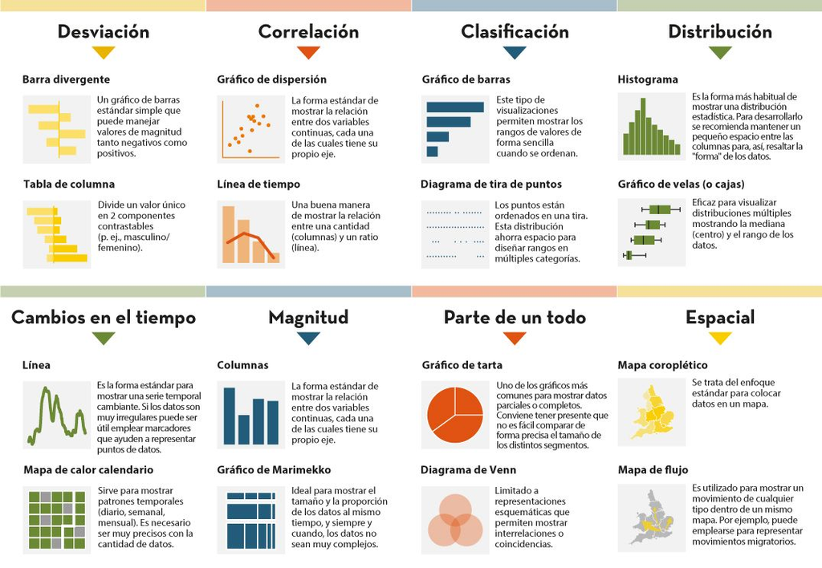

R ya trae herramientas para hacer graficos pero estas son basicas

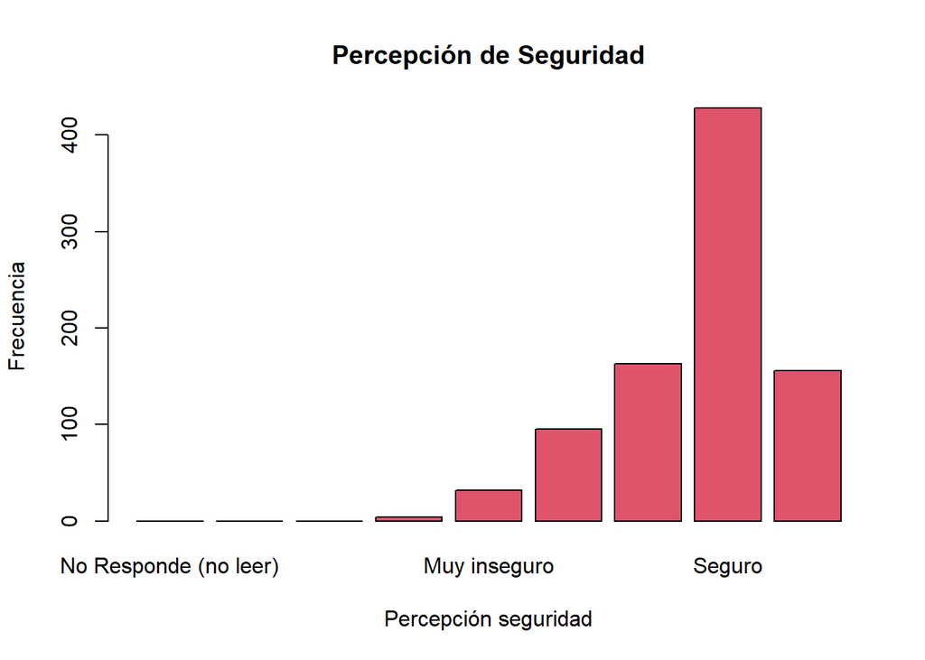

```r
#Gráfico de barras

plot(as_factor(basefiltrada$perseg),
     main= "Percepción de Seguridad",
     xlab= "Percepción seguridad",
     ylab= "Frecuencia", col=2)
```

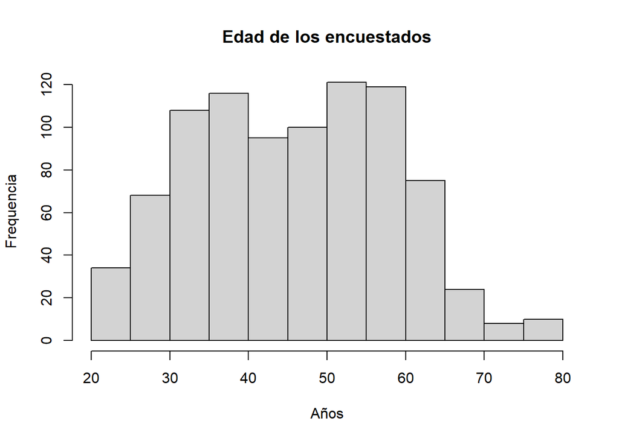

```r
#histograma

hist(basefiltrada$edad,main="Edad de los encuestados", xlab="Años",ylab="Frequencia")
```

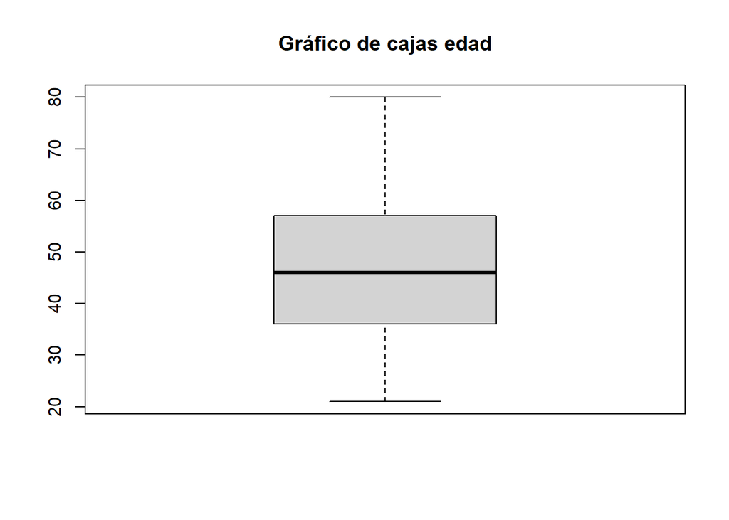

```r
#Boxplot

boxplot(basefiltrada $edad, main = "Gráfico de cajas edad",
        outline = TRUE)
```